# STAT 380 Taryn

# Libraries

```r
library(ggplot2)
library(dplyr)
library(tidyverse)
```

# Dataset

```r
SpotifyDataset <- read.csv(file = "SpotifyDataset.csv", stringsAsFactors = FALSE)

colnames(SpotifyDataset)
```

```
 [1] "Track.URI"            "Track.Name"           "Artist.URI.s."        "Artist.Name.s."       "Album.URI"
 [6] "Album.Name"           "Album.Artist.URI.s."  "Album.Artist.Name.s." "Album.Release.Date"   "Album.Image.URL"
[11] "Disc.Number"          "Track.Number"         "Track.Duration..ms."  "Track.Preview.URL"    "Explicit"
[16] "Popularity"           "ISRC"                 "Added.By"             "Added.At"             "Artist.Genres"
[21] "Danceability"         "Energy"               "Key"                  "Loudness"             "Mode"
[26] "Speechiness"          "Acousticness"         "Instrumentalness"     "Liveness"             "Valence"
[31] "Tempo"                "Time.Signature"       "Album.Genres"         "Label"                "Copyrights"
```

```r
# Edit this to the columns we want to use
SpotifyDataset <- SpotifyDataset%>%
  select(Track.Name, Artist.Name.s., Popularity, Artist.Genres, Danceability, Energy, Key, Loudness, Speechiness, Acousticness, Instrumentalness, Liveness, Valence, Tempo)

colnames(SpotifyDataset)
```

```
 [1] "Track.Name"       "Artist.Name.s."   "Popularity"       "Artist.Genres"    "Danceability"     "Energy"
 [7] "Key"              "Loudness"         "Speechiness"      "Acousticness"     "Instrumentalness" "Liveness"
[13] "Valence"          "Tempo"
```

```r
SDNums <- SpotifyDataset%>%
  select(Popularity,Danceability, Energy, Key, Loudness, Speechiness, Acousticness, Instrumentalness, Liveness, Valence, Tempo)
```

# By Genre

```r
split <- strsplit(as.character(SpotifyDataset$Artist.Genres), ",")

first <- sapply(split, function(x) trimws(x[1]))

SpotifyDataset$Genre <- first

sd1 <-sdMorePop <- SpotifyDataset%>%
  group_by(Genre)%>%
  summarise(count = n())

sdMorePop <- SpotifyDataset%>%
  group_by(Genre)%>%
  summarise(count = n())%>%
  filter(count >= 20)
# bc 10000/502

sdMorePop2 <- right_join(SpotifyDataset, sdMorePop)
sdMorePop2 <- sdMorePop2%>%
  select(Track.Name, Artist.Name.s., Genre, Popularity,Danceability, Energy, Key, Loudness, Speechiness, Acousticness, Instrumentalness, Liveness, Valence, Tempo)

sdLessPop <- SpotifyDataset%>%
  group_by(Genre)%>%
  summarise(count = n())%>%
  filter(count < 20)
# bc 10000/502

sdLessPop2 <- right_join(SpotifyDataset, sdLessPop)
```

## Test

5 + songs per genre and 50 + Median POp

[output not shown]

[output cut: 990 more lines]

### summary stats

```r
stats <- function(data, names) {
  for (variable in names) {
    variableData <- data[, variable, drop = FALSE]
    print(
      summary(variableData)
    )
  }
}

variables <- colnames(SDNums)
stats(test2, variables)
```

```
   Popularity
 Min.   : 0.00
 1st Qu.:13.00
 Median :57.00
 Mean   :46.73
 3rd Qu.:71.00
 Max.   :98.00
  Danceability
 Min.   :0.129
 1st Qu.:0.522
 Median :0.630
 Mean   :0.617
 3rd Qu.:0.720
 Max.   :0.988
     Energy
 Min.   :0.0000203
 1st Qu.:0.5850000
 Median :0.7190000
 Mean   :0.6938971
 3rd Qu.:0.8320000
 Max.   :0.9930000
      Key
 Min.   : 0.000
 1st Qu.: 2.000
 Median : 5.000
 Mean   : 5.177
 3rd Qu.: 8.000
 Max.   :11.000
    Loudness
 Min.   :-25.420
 1st Qu.: -8.198
 Median : -6.063
 Mean   : -6.789
 3rd Qu.: -4.711
 Max.   : -1.248
  Speechiness
 Min.   :0.0224
 1st Qu.:0.0343
 Median :0.0454
 Mean   :0.0698
```

[output cut: 22 more lines]

```
 Max.   :0.9700
    Valence
 Min.   :0.0350
 1st Qu.:0.3770
 Median :0.5690
 Mean   :0.5635
 3rd Qu.:0.7550
 Max.   :0.9880
     Tempo
 Min.   : 59.41
 1st Qu.:102.33
 Median :120.08
 Mean   :121.70
 3rd Qu.:135.06
 Max.   :217.91
```

### his

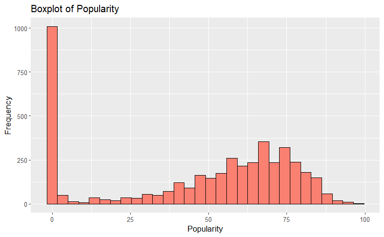

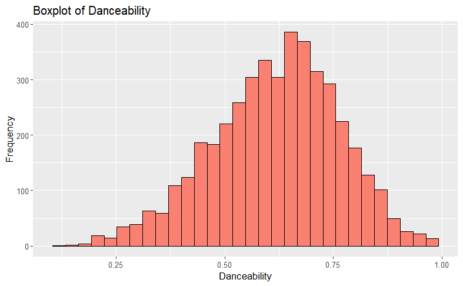

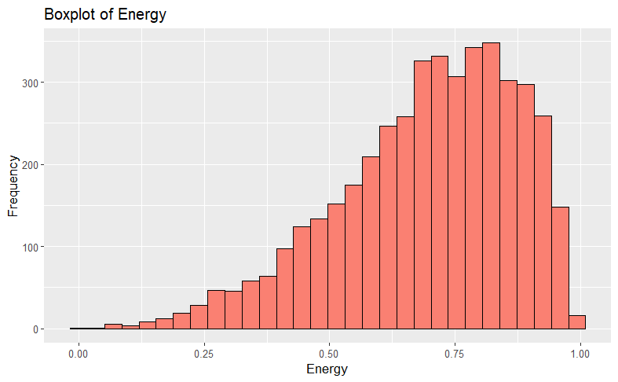

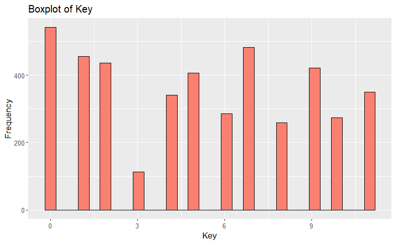

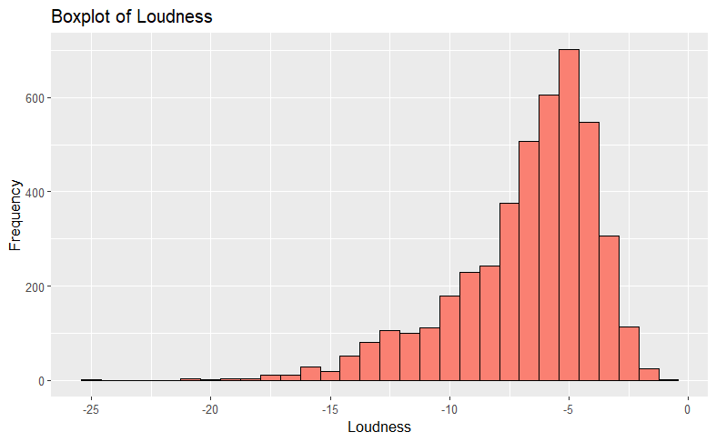

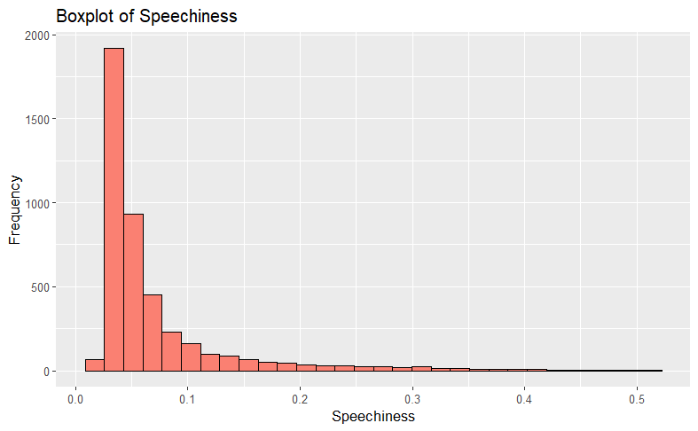

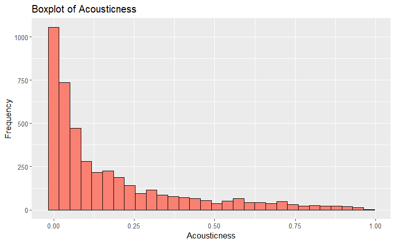

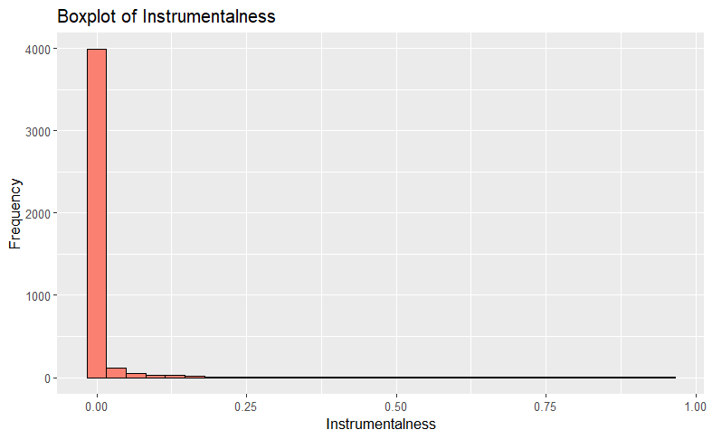

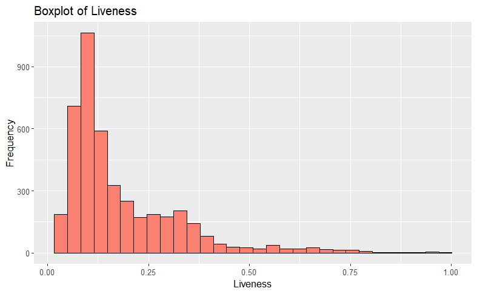

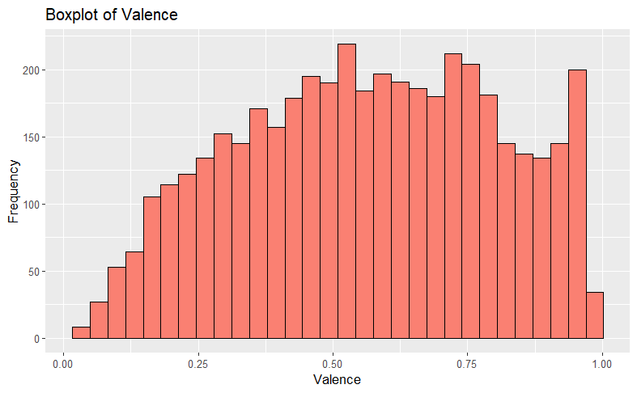

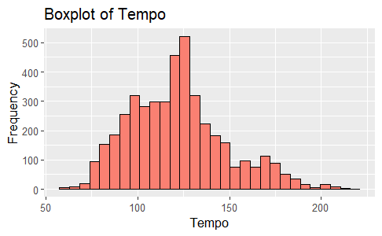

```r
histograms <- function(data, names) {
  for (variable in names) {
    variableData <- data[, variable, drop = FALSE]

    print(ggplot(
      data = variableData,
      mapping = aes(x = !!as.name(variable))) +
        geom_histogram(color = "black", fill = "salmon") +
        labs(title = paste("Boxplot of", variable),
             x = variable, y = "Frequency")
    )
  }
}
histograms(test2, variables)
```

### pairs/cors

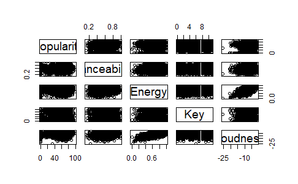

```r
nums1 <- test2%>%
  select(Popularity,Danceability, Energy, Key, Loudness)

nums2 <-test2%>%
  select(Popularity, Speechiness, Acousticness, Instrumentalness, )

nums3 <- test2%>%
  select(Popularity, Liveness, Valence, Tempo)

#pairs(SDNums)
pairs(nums1)
```

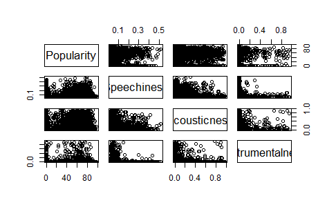

```r
pairs(nums2)
```

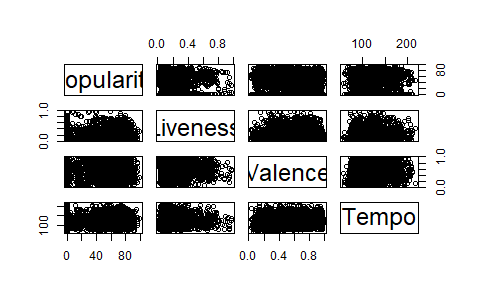

[figure not shown]

```r
pairs(nums3)
```

```r
cor(nums1, use = "complete.obs")
```

```
               Popularity Danceability       Energy        Key     Loudness
Popularity    1.000000000  0.007729667 -0.006174291 0.01370133 -0.006454304
Danceability  0.007729667  1.000000000  0.075219614 0.02156935  0.093045277
Energy       -0.006174291  0.075219614  1.000000000 0.05818343  0.662175948
Key           0.013701331  0.021569346  0.058183427 1.00000000  0.044642527
Loudness     -0.006454304  0.093045277  0.662175948 0.04464253  1.000000000
```

```r
cor(nums2, use = "complete.obs")
```

```
                  Popularity Speechiness Acousticness Instrumentalness
Popularity        1.00000000 -0.01608721   0.03289909      -0.01300162
Speechiness      -0.01608721  1.00000000  -0.08478156      -0.03476555
Acousticness      0.03289909 -0.08478156   1.00000000      -0.02465813
Instrumentalness -0.01300162 -0.03476555  -0.02465813       1.00000000
```

```r
cor(nums3, use = "complete.obs")
```

```
            Popularity    Liveness    Valence       Tempo
Popularity  1.00000000 -0.02120988 0.01826596 -0.02514363
Liveness   -0.02120988  1.00000000 0.01143784  0.03520678
Valence     0.01826596  0.01143784 1.00000000  0.01642763
Tempo      -0.02514363  0.03520678 0.01642763  1.00000000
```

## Genre EDA for more popular songs

### boxplots

````r
test2```
````

```
Error: attempt to use zero-length variable name
```

### histrograms

```r
histograms <- function(data, names) {
  for (variable in names) {
    variableData <- data[, variable, drop = FALSE]

    print(ggplot(
      data = variableData,
      mapping = aes(x = !!as.name(variable))) +
        geom_histogram(color = "black", fill = "salmon") +
        labs(title = paste("Boxplot of", variable),
             x = variable, y = "Frequency")
    )
  }
}


variables <- colnames(SDNums)
histograms(sdMorePop2, variables)
```

[output not shown]

### pairs/cor

```r
nums1 <- sdMorePop2%>%
  select(Popularity,Danceability, Energy, Key, Loudness)

nums2 <- sdMorePop2%>%
  select(Popularity, Speechiness, Acousticness, Instrumentalness, )

nums3 <- sdMorePop2%>%
  select(Popularity, Liveness, Valence, Tempo)

#pairs(SDNums)
pairs(nums1)
pairs(nums2)
pairs(nums3)
```

[output not shown]

### summary stats

```r
stats(sdMorePop2, variables)
```

[output not shown]

## Genre EDA for more less pop songs

### boxplots

```r
boxplots_by_genre <- function(data, genres, pop) {
  unique <- unique(data[[genres]])

  for (genre in unique) {
    genre_data <- data[data[[genres]] == genre, ]

    print(ggplot(
      data = genre_data,
      mapping = aes(x = 1, y = !!as.name(pop))
    ) +
      geom_boxplot() +
      labs(title = paste("Boxplot of", pop, "for", genre),
           x = genre, y = pop) +
      theme(axis.title.x=element_blank(),
            axis.text.x=element_blank(),
            axis.ticks.x=element_blank())
    )
  }
}

boxplots_by_genre(sdLessPop2, "Genre", "Popularity")
```

[output not shown]

### summary stats

```r
stats(sdLessPop2, variables)
```

[output not shown]

# General Data

## Summary Statistics

```r
stats(SDNums, variables)
```

[output not shown]

## Boxplots

```r
boxplots <- function(data, names) {
  for (variable in names) {
    variableData <- data[, variable, drop = FALSE]

    # Create a boxplot using ggplot2
    print(ggplot(
      data = variableData,
      mapping = aes(y = !!as.name(variable))) +
        geom_boxplot() +
        labs(title = paste("Boxplot of", variable),
             x = "", y = variable)
    )
  }
}

boxplots(SDNums, variables)
```

[output not shown]

## Histograms

```r
histograms <- function(data, names) {
  for (variable in names) {
    variableData <- data[, variable, drop = FALSE]

    print(ggplot(
      data = variableData,
      mapping = aes(x = !!as.name(variable))) +
        geom_histogram(color = "black", fill = "salmon") +
        labs(title = paste("Histogram of", variable),
             x = variable, y = "Frequency")
    )
  }
}

histograms(SDNums, variables)
```

[output not shown]

There are many songs with a popularity of 0, why is that? Key is not symmetrical.

## Observations for individual factors

*Popularity:* There are a lot of songs with a popularity of 0, not sure why that is, but it makes it skewed. Without that, it would be fairly symmetrical.  
*Danceability:* Pretty symmetrical with a center around .60-.61  
*Energy:* Fairly symmetrical, slightly skewed left with center around .68-.71. *Key:* Numbers wise, the mean and median are very similar 5.168 and 5, respectively. When looking at the graph, it does not have a distinct shape, with the a key of 3 being the least chosen and 0 being the most.

```r
SDNums%>%
  group_by(Key)%>%
  summarise(count = n())%>%
  arrange(desc(count))
```

[output not shown]

*Speechiness:* Heavily skewed right. With mean of 0.06 and median of 0.04.  
*Acousticness:* Heavily skewed right. With mean of .21 and median of .096.  
*Instrumentalness:* Heavily skewed right. With mean of 0.029 and median of 0.0000057.  
*Liveness:*Heavily skewed right. With mean of .18 and median of .12. *Valence:* Numbers wise it is symmetrical but it is more box/square shaped with center around .58.  
*Tempo:* Fairly symmetrical with center around 120-121.

## Scatterplot

Factors on the y axis, popularity on the x axis.

```r
scatter <- function(data, names) {
  pop <- colnames(data)[sapply(data, is.numeric)][1]
  for (variable in names) {
    variableData <- data[, c(variable, pop), drop = FALSE]

    print(ggplot(
      data = variableData,
      mapping = aes(x = !!as.name(variable), y = !!as.name(pop))) +
        geom_point() +
        labs(title = paste("Scatter Plot of", variable),
             x = variable, y = pop)
    )
  }
}

scatter(SDNums, variables)
```

[output not shown]

No clear patterns or correlation between popularity and a variable.

## Pairs/Cor

Had to split it up into 3 because it was too small. All have population though

```r
nums1 <- SpotifyDataset%>%
  select(Popularity,Danceability, Energy, Key, Loudness)

nums2 <- SpotifyDataset%>%
  select(Popularity, Speechiness, Acousticness, Instrumentalness, )

nums3 <- SpotifyDataset%>%
  select(Popularity, Liveness, Valence, Tempo)

#pairs(SDNums)
pairs(nums1)
pairs(nums2)
pairs(nums3)

cor(SDNums, use = "complete.obs")
```

[output not shown]

Popularity does not really have a pattern with any variable. The only variables with a slight linear pattern are energy and loudness. Could be more but they are split up.